# Running Different GARCH Models

Vincent Tandaw

2023-03-25

## 1. Read Libraries

```r
# Read Libraries
library(quantmod)
library(fGarch)
library(moments)
library(padr)
```

## 2. Read the Data

```r
# Read Data
getSymbols("DJI",from="1991-01-01", to="2019-06-30")
```

```
#> [1] "DJI"
```

## 3. Data Wrangling

Transform data into daily returns and plot the series to see what we are dealing with.

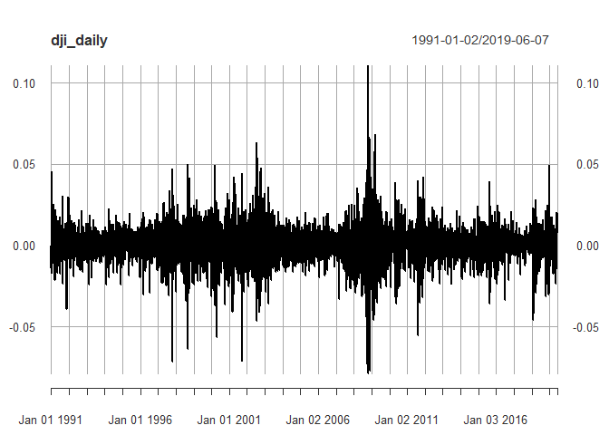

```r
dji_daily = dailyReturn(DJI, subset=NULL, type='arithmetic', leading=TRUE)
plot(dji_daily)
```

As shown above, the series exhibits huge spikes around 2008-2010, which could hint at the nonstationarity of the series.

```r
dji_daily = as.numeric(dji_daily)
dji_daily = na.omit(dji_daily)
```

We remove NAs and transform data into numeric to build an AR model for the mean equation

## 4. AR Mean Equation

```r
ar.mle(dji_daily ,order.max=5)
```

```
#>
#> Call:
#> ar.mle(x = dji_daily, order.max = 5)
#>
#> Coefficients:
#>       1        2        3        4        5
#> -0.0525  -0.0425   0.0123  -0.0125  -0.0435
#>
#> Order selected 5  sigma^2 estimated as  0.000111
```

```r
dji_ar2 = arima(dji_daily,order=c(2,0,0))
```

```r
pred4 <- predict(dji_ar2, n.ahead=4)
#lowerbound
for (x in 1:length(pred4$pred)) {
    print(pred4$pred[x]-1.645*pred4$se[x])}
```

```
#> [1] -0.018213
#> [1] -0.01767189
#> [1] -0.01692189
#> [1] -0.01698709
```

```r
#upperbound
for (x in 1:length(pred4$pred)) {
    print(pred4$pred[x]+1.645*pred4$se[x])}
```

```
#> [1] 0.01648694
#> [1] 0.01707658
#> [1] 0.01785526
#> [1] 0.01779041
```

The final results are:

[output not shown]

## 5. Confirm if GARCH effects are present

We find that though the series is serially uncorrelated, the ACF and PACF of the square of the series and the series in absolute terms exhibit some serial correlation. Thus, the series is serially uncorrelated but weakly dependent.

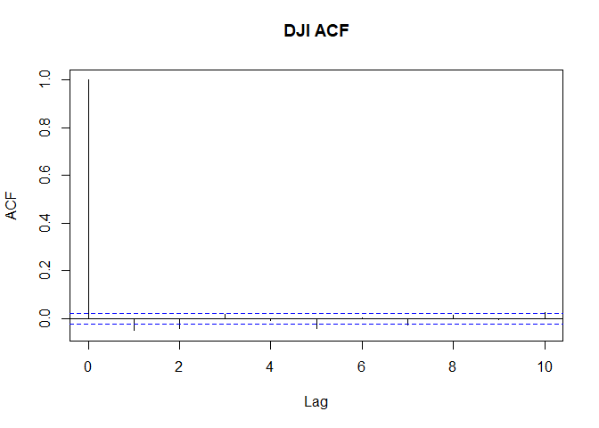

```r
acf(dji_daily, lag.max=10,main='DJI ACF')
```

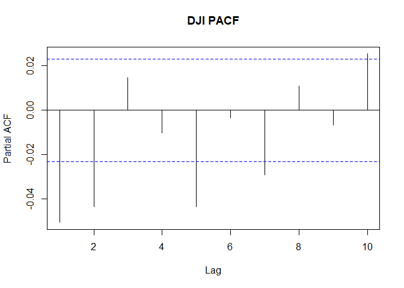

```r
pacf(dji_daily, lag.max=10,main='DJI PACF')
```

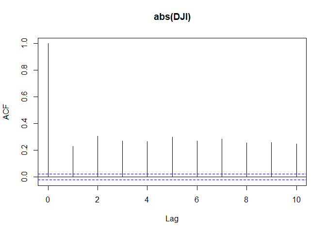

```r
acf(abs(dji_daily), lag.max=10, main='abs(DJI)')
```

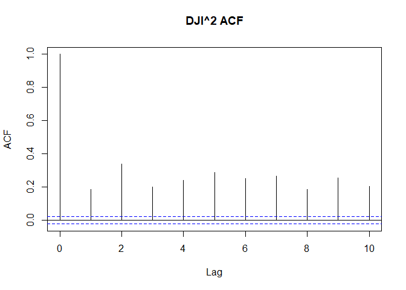

```r
acf(dji_daily^2, lag.max=10,main='DJI^2 ACF')
```

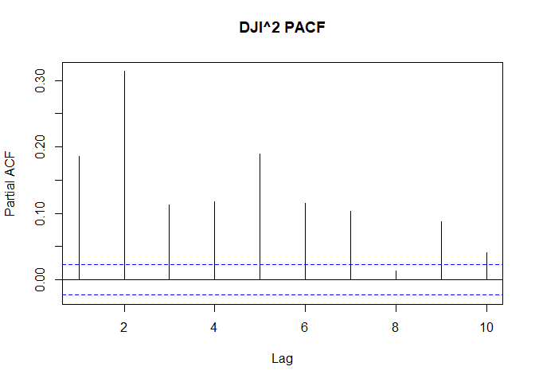

```r
pacf(dji_daily^2, lag.max=10,main='DJI^2 PACF')
```

## 6.1 Building the ARMA(2,0)+GARCH(1,1) models

```r
mod1 = garchFit(~arma(2,0)+garch(1,1),data=dji_daily,trace=F)
summary(mod1)
```

```
#>
#> Title:
#>  GARCH Modelling
#>
#> Call:
#>  garchFit(formula = ~arma(2, 0) + garch(1, 1), data = dji_daily,
#>     trace = F)
#>
#> Mean and Variance Equation:
#>  data ~ arma(2, 0) + garch(1, 1)
#> <environment: 0x0000015162914f58>
#>  [data = dji_daily]
#>
#> Conditional Distribution:
#>  norm
#>
#> Coefficient(s):
#>          mu          ar1          ar2        omega       alpha1        beta1
#>  0.00064631  -0.01645859  -0.00219879   0.00000159   0.09485680   0.89021719
#>
#> Std. Errors:
#>  based on Hessian
#>
#> Error Analysis:
#>          Estimate  Std. Error  t value Pr(>|t|)
#> mu      6.463e-04   9.035e-05    7.153 8.47e-13 ***
#> ar1    -1.646e-02   1.274e-02   -1.292    0.196
#> ar2    -2.199e-03   1.257e-02   -0.175    0.861
#> omega   1.590e-06   2.166e-07    7.342 2.10e-13 ***
#> alpha1  9.486e-02   7.200e-03   13.174  < 2e-16 ***
#> beta1   8.902e-01   7.955e-03  111.903  < 2e-16 ***
#> ---
#> Signif. codes:  0 '***' 0.001 '**' 0.01 '*' 0.05 '.' 0.1 ' ' 1
#>
#> Log Likelihood:
#>  23772.4    normalized:  3.321095
#>
#> Description:
#>  Sat Mar 25 17:03:47 2023 by user: vince
#>
#>
#> Standardised Residuals Tests:
#>                                 Statistic p-Value
#>  Jarque-Bera Test   R    Chi^2  1277.502  0
#>  Shapiro-Wilk Test  R    W      NA        NA
#>  Ljung-Box Test     R    Q(10)  15.9743   0.1003704
#>  Ljung-Box Test     R    Q(15)  32.41446  0.005651344
#>  Ljung-Box Test     R    Q(20)  34.13183  0.0252466
#>  Ljung-Box Test     R^2  Q(10)  9.597485  0.4764877
#>  Ljung-Box Test     R^2  Q(15)  12.9574   0.6055884
#>  Ljung-Box Test     R^2  Q(20)  15.69569  0.7353147
#>  LM Arch Test       R    TR^2   11.05164  0.5244985
#>
#> Information Criterion Statistics:
#>       AIC       BIC       SIC      HQIC
#> -6.640513 -6.634749 -6.640514 -6.638529
```

Verifying the model’s validity requires the use of the Box-Ljung test of the series and the square of the series not to exhibit any serial correlation. The Ljung-Box test for the standardized residuals gives Q(10)=15.97 with p-value of 0.10, while the test for squared standardized residuals gives Q(10)=9.598 with p-value of 0.47. This is a step closer to verifying the model

```r
Box.test(mod1@residuals/mod1@sigma.t,lag=10,type='Ljung')
```

```
#>
#>  Box-Ljung test
#>
#> data:  mod1@residuals/mod1@sigma.t
#> X-squared = 15.974, df = 10, p-value = 0.1004
```

```r
Box.test((mod1@residuals/mod1@sigma.t)^2,lag=10,type='Ljung')
```

```
#>
#>  Box-Ljung test
#>
#> data:  (mod1@residuals/mod1@sigma.t)^2
#> X-squared = 9.5975, df = 10, p-value = 0.4765
```

We note that the AR lags were nonsignificant, so we cannot be sure that these lags provide meaningful information to the model. Thus, we rerun the model with no ARMA terms i.e. just the volatility equation along with the Q-tests.

```r
mod2 = garchFit(~arma(0,0)+garch(1,1),data=dji_daily,trace=F)
summary(mod2)
```

```
#>
#> Title:
#>  GARCH Modelling
#>
#> Call:
#>  garchFit(formula = ~arma(0, 0) + garch(1, 1), data = dji_daily,
#>     trace = F)
#>
#> Mean and Variance Equation:
#>  data ~ arma(0, 0) + garch(1, 1)
#> <environment: 0x000001516893fe10>
#>  [data = dji_daily]
#>
#> Conditional Distribution:
#>  norm
#>
#> Coefficient(s):
#>         mu       omega      alpha1       beta1
#> 6.3436e-04  1.5978e-06  9.5292e-02  8.8971e-01
#>
#> Std. Errors:
#>  based on Hessian
#>
#> Error Analysis:
#>         Estimate  Std. Error  t value Pr(>|t|)
#> mu     6.344e-04   8.953e-05    7.085 1.39e-12 ***
#> omega  1.598e-06   2.171e-07    7.359 1.85e-13 ***
#> alpha1 9.529e-02   7.220e-03   13.198  < 2e-16 ***
#> beta1  8.897e-01   7.976e-03  111.548  < 2e-16 ***
#> ---
#> Signif. codes:  0 '***' 0.001 '**' 0.01 '*' 0.05 '.' 0.1 ' ' 1
#>
#> Log Likelihood:
#>  23771.34    normalized:  3.320947
#>
#> Description:
#>  Sat Mar 25 17:03:47 2023 by user: vince
#>
#>
#> Standardised Residuals Tests:
#>                                 Statistic p-Value
#>  Jarque-Bera Test   R    Chi^2  1259.379  0
#>  Shapiro-Wilk Test  R    W      NA        NA
#>  Ljung-Box Test     R    Q(10)  15.15131  0.126642
#>  Ljung-Box Test     R    Q(15)  31.66261  0.00715415
#>  Ljung-Box Test     R    Q(20)  33.38409  0.03060577
#>  Ljung-Box Test     R^2  Q(10)  10.11154  0.4307624
#>  Ljung-Box Test     R^2  Q(15)  13.52215  0.5620346
#>  Ljung-Box Test     R^2  Q(20)  16.33979  0.6953332
#>  LM Arch Test       R    TR^2   11.06012  0.5237737
#>
#> Information Criterion Statistics:
#>       AIC       BIC       SIC      HQIC
#> -6.640776 -6.636933 -6.640776 -6.639453
```

```r
Box.test(mod2@residuals/mod2@sigma.t,lag=10,type='Ljung')
```

```
#>
#>  Box-Ljung test
#>
#> data:  mod2@residuals/mod2@sigma.t
#> X-squared = 15.151, df = 10, p-value = 0.1266
```

```r
Box.test((mod2@residuals/mod2@sigma.t)^2,lag=10,type='Ljung')
```

```
#>
#>  Box-Ljung test
#>
#> data:  (mod2@residuals/mod2@sigma.t)^2
#> X-squared = 10.112, df = 10, p-value = 0.4308
```

THis time, all the variables are significant to the 0.1% level. The Q-statistic for the standardized shocks is 15.151 with p-value of 0.1266, while the squared standardized shocks give Q(10)=10.112 with p-value of 0.43

### 6.2 GARCH with Student’s t Innovations

Just for completeness, we rerun the same specification under a different assumption. As a result, the fitted model does change, albeit slightly.

```r
mod3 = garchFit(~arma(2,0)+garch(1,1),data=dji_daily,trace=F,cond.dist=c("std"))
summary(mod3)
```

```
#>
#> Title:
#>  GARCH Modelling
#>
#> Call:
#>  garchFit(formula = ~arma(2, 0) + garch(1, 1), data = dji_daily,
#>     cond.dist = c("std"), trace = F)
#>
#> Mean and Variance Equation:
#>  data ~ arma(2, 0) + garch(1, 1)
#> <environment: 0x000001516aaf4550>
#>  [data = dji_daily]
#>
#> Conditional Distribution:
#>  std
#>
#> Coefficient(s):
#>          mu          ar1          ar2        omega       alpha1        beta1
#>  7.3180e-04  -2.6821e-02  -1.4110e-02   1.0004e-06   8.8662e-02   9.0499e-01
#>       shape
#>  6.4073e+00
#>
#> Std. Errors:
#>  based on Hessian
#>
#> Error Analysis:
#>          Estimate  Std. Error  t value Pr(>|t|)
#> mu      7.318e-04   8.461e-05    8.649  < 2e-16 ***
#> ar1    -2.682e-02   1.192e-02   -2.251   0.0244 *
#> ar2    -1.411e-02   1.202e-02   -1.174   0.2403
#> omega   1.000e-06   2.068e-07    4.838 1.31e-06 ***
#> alpha1  8.866e-02   8.425e-03   10.524  < 2e-16 ***
#> beta1   9.050e-01   8.573e-03  105.562  < 2e-16 ***
#> shape   6.407e+00   4.812e-01   13.315  < 2e-16 ***
#> ---
#> Signif. codes:  0 '***' 0.001 '**' 0.01 '*' 0.05 '.' 0.1 ' ' 1
#>
#> Log Likelihood:
#>  23936.93    normalized:  3.344081
#>
#> Description:
#>  Sat Mar 25 17:03:49 2023 by user: vince
#>
#>
#> Standardised Residuals Tests:
#>                                 Statistic p-Value
#>  Jarque-Bera Test   R    Chi^2  1479.439  0
#>  Shapiro-Wilk Test  R    W      NA        NA
#>  Ljung-Box Test     R    Q(10)  19.71323  0.03208471
#>  Ljung-Box Test     R    Q(15)  36.33461  0.001581464
#>  Ljung-Box Test     R    Q(20)  38.27508  0.008194601
#>  Ljung-Box Test     R^2  Q(10)  10.55289  0.393395
#>  Ljung-Box Test     R^2  Q(15)  15.49556  0.4163449
#>  Ljung-Box Test     R^2  Q(20)  19.94436  0.4614153
#>  LM Arch Test       R    TR^2   12.56712  0.4012729
#>
#> Information Criterion Statistics:
#>       AIC       BIC       SIC      HQIC
#> -6.686205 -6.679481 -6.686207 -6.683891
```

```r
Box.test(mod3@residuals/mod3@sigma.t,lag=10,type='Ljung')
```

```
#>
#>  Box-Ljung test
#>
#> data:  mod3@residuals/mod3@sigma.t
#> X-squared = 19.713, df = 10, p-value = 0.03208
```

```r
Box.test((mod3@residuals/mod3@sigma.t)^2,lag=10,type='Ljung')
```

```
#>
#>  Box-Ljung test
#>
#> data:  (mod3@residuals/mod3@sigma.t)^2
#> X-squared = 10.553, df = 10, p-value = 0.3934
```

This time, the first AR lag is significant at the 5% level.

And, the Ljung-Box test for the standardized residuals gives Q(10)=19.713 with p-value of 0.03, which indicates that the model may not be adequate. Meanwhile, the test for squared standardized residuals gives Q(10)=10.553 with p-value of 0.39.

Therefore, we rerun the model as an ARMA(1,0) + GARCH(1,1):

```r
mod4 = garchFit(~arma(1,0)+garch(1,1),data=dji_daily,trace=F,cond.dist=c("std"))
summary(mod4)
```

```
#>
#> Title:
#>  GARCH Modelling
#>
#> Call:
#>  garchFit(formula = ~arma(1, 0) + garch(1, 1), data = dji_daily,
#>     cond.dist = c("std"), trace = F)
#>
#> Mean and Variance Equation:
#>  data ~ arma(1, 0) + garch(1, 1)
#> <environment: 0x000001516c1cfa18>
#>  [data = dji_daily]
#>
#> Conditional Distribution:
#>  std
#>
#> Coefficient(s):
#>          mu          ar1        omega       alpha1        beta1        shape
#>  7.1925e-04  -2.6610e-02   1.0056e-06   8.8991e-02   9.0457e-01   6.4421e+00
#>
#> Std. Errors:
#>  based on Hessian
#>
#> Error Analysis:
#>          Estimate  Std. Error  t value Pr(>|t|)
#> mu      7.192e-04   8.397e-05    8.565  < 2e-16 ***
#> ar1    -2.661e-02   1.191e-02   -2.233   0.0255 *
#> omega   1.006e-06   2.072e-07    4.854 1.21e-06 ***
#> alpha1  8.899e-02   8.435e-03   10.550  < 2e-16 ***
#> beta1   9.046e-01   8.586e-03  105.354  < 2e-16 ***
#> shape   6.442e+00   4.856e-01   13.267  < 2e-16 ***
#> ---
#> Signif. codes:  0 '***' 0.001 '**' 0.01 '*' 0.05 '.' 0.1 ' ' 1
#>
#> Log Likelihood:
#>  23935.04    normalized:  3.343816
#>
#> Description:
#>  Sat Mar 25 17:03:50 2023 by user: vince
#>
#>
#> Standardised Residuals Tests:
#>                                 Statistic p-Value
#>  Jarque-Bera Test   R    Chi^2  1444.591  0
#>  Shapiro-Wilk Test  R    W      NA        NA
#>  Ljung-Box Test     R    Q(10)  17.89211  0.05681107
#>  Ljung-Box Test     R    Q(15)  34.86792  0.002567752
#>  Ljung-Box Test     R    Q(20)  36.84699  0.01220619
#>  Ljung-Box Test     R^2  Q(10)  10.77854  0.3750303
#>  Ljung-Box Test     R^2  Q(15)  15.75174  0.3987403
#>  Ljung-Box Test     R^2  Q(20)  20.2772   0.4407137
#>  LM Arch Test       R    TR^2   12.37138  0.4163329
#>
#> Information Criterion Statistics:
#>       AIC       BIC       SIC      HQIC
#> -6.685956 -6.680192 -6.685957 -6.683972
```

```r
Box.test(mod4@residuals/mod4@sigma.t,lag=10,type='Ljung')
```

```
#>
#>  Box-Ljung test
#>
#> data:  mod4@residuals/mod4@sigma.t
#> X-squared = 17.892, df = 10, p-value = 0.05681
```

```r
Box.test((mod4@residuals/mod4@sigma.t)^2,lag=10,type='Ljung')
```

```
#>
#>  Box-Ljung test
#>
#> data:  (mod4@residuals/mod4@sigma.t)^2
#> X-squared = 10.779, df = 10, p-value = 0.375
```

The Ljung-Box test statistic for the standardized residuals is Q(10) = 17.892 with p-value 0.05681, which although does pass the “Fisher’s 5%”, may still not be enough to satisfy skeptics. Meanwhile, the test statistic for the squared standardized residuals is Q(10) = 10.779 with p-value of 0.375.

## 7. Fitted Model Equations

The breakdown of full models from above is as follows:

1. Models with Gaussian innovations:
   1. ARMA(2,0) + GARCH(1,1)

      $$r_t = 6.463 \cdot 10^{-4} + a_t$$
      $$σ^2_t = 1.590 \cdot 10^{-6} + 9.486 \cdot
      10^{-2} a_{t-1}^2 + 0.8902 σ_{t-1}^2$$
   2. ARMA(0,0) + GARCH(1,1)